# Advanced Customer Churn Analysis & Prediction Report

Abeer Gaber | Data Analyst

2026-08-25

## ## 1. Executive Summary

This report aims to investigate and identify the primary drivers of Customer Churn for a telecommunications provider. Using statistical modeling (Logistic Regression), we predict customers at high risk of leaving to enable targeted, proactive retention campaigns.

## ## 2. Data Loading & Pre-processing

In this step, customer records are loaded, cleaned, and categorical variables are encoded for statistical modeling:

```r
data <- read.csv("D:/Data Analysis/customers_churn/Telco-Customer-Churn.csv")

data_cleaned <- data %>%
  mutate(
    Churn_Numeric = ifelse(Churn == "Yes", 1, 0),
    Churn = as.factor(Churn),
    Contract = as.factor(Contract),
    InternetService = as.factor(InternetService),
    TechSupport = as.factor(TechSupport),
    PaymentMethod = as.factor(PaymentMethod)
  ) %>%
  filter(!is.na(MonthlyCharges))

glimpse(data_cleaned)
```

```
## Rows: 7,043
## Columns: 22
## $ customerID       <chr> "7590-VHVEG", "5575-GNVDE", "3668-QPYBK", "7795-CFOCW…
## $ gender           <chr> "Female", "Male", "Male", "Male", "Female", "Female",…
## $ SeniorCitizen    <int> 0, 0, 0, 0, 0, 0, 0, 0, 0, 0, 0, 0, 0, 0, 0, 0, 0, 0,…
## $ Partner          <chr> "Yes", "No", "No", "No", "No", "No", "No", "No", "Yes…
## $ Dependents       <chr> "No", "No", "No", "No", "No", "No", "Yes", "No", "No"…
## $ tenure           <int> 1, 34, 2, 45, 2, 8, 22, 10, 28, 62, 13, 16, 58, 49, 2…
## $ PhoneService     <chr> "No", "Yes", "Yes", "No", "Yes", "Yes", "Yes", "No", …
## $ MultipleLines    <chr> "No phone service", "No", "No", "No phone service", "…
## $ InternetService  <fct> DSL, DSL, DSL, DSL, Fiber optic, Fiber optic, Fiber o…
## $ OnlineSecurity   <chr> "No", "Yes", "Yes", "Yes", "No", "No", "No", "Yes", "…
## $ OnlineBackup     <chr> "Yes", "No", "Yes", "No", "No", "No", "Yes", "No", "N…
## $ DeviceProtection <chr> "No", "Yes", "No", "Yes", "No", "Yes", "No", "No", "Y…
## $ TechSupport      <fct> No, No, No, Yes, No, No, No, No, Yes, No, No, No inte…
## $ StreamingTV      <chr> "No", "No", "No", "No", "No", "Yes", "Yes", "No", "Ye…
## $ StreamingMovies  <chr> "No", "No", "No", "No", "No", "Yes", "No", "No", "Yes…
## $ Contract         <fct> Month-to-month, One year, Month-to-month, One year, M…
## $ PaperlessBilling <chr> "Yes", "No", "Yes", "No", "Yes", "Yes", "Yes", "No", …
## $ PaymentMethod    <fct> Electronic check, Mailed check, Mailed check, Bank tr…
## $ MonthlyCharges   <dbl> 29.85, 56.95, 53.85, 42.30, 70.70, 99.65, 89.10, 29.7…
## $ TotalCharges     <dbl> 29.85, 1889.50, 108.15, 1840.75, 151.65, 820.50, 1949…
## $ Churn            <fct> No, No, Yes, No, Yes, Yes, No, No, Yes, No, No, No, N…
## $ Churn_Numeric    <dbl> 0, 0, 1, 0, 1, 1, 0, 0, 1, 0, 0, 0, 0, 1, 0, 0, 0, 0,…
```

## ## 3. Exploratory Visualizations (EDA)

### A) Churn Rate Distribution by Contract Type

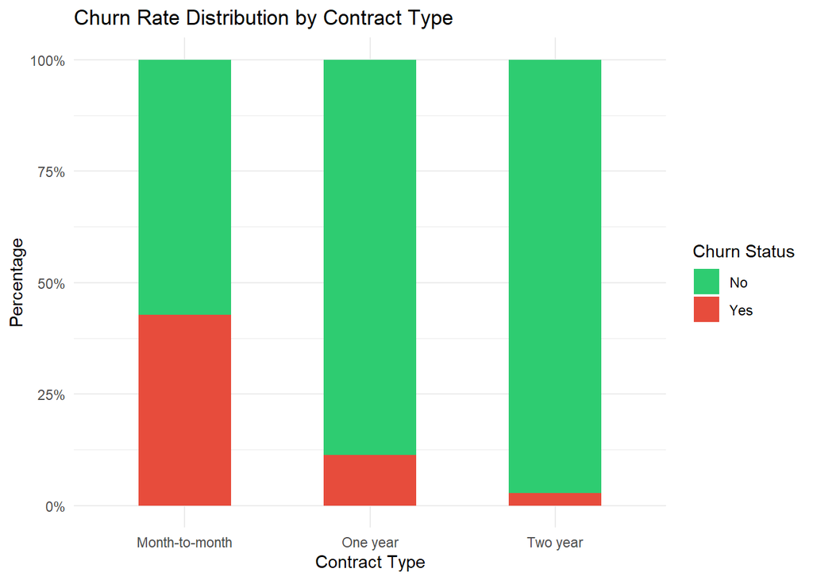

```r
ggplot(data_cleaned, aes(x = Contract, fill = Churn)) +
  geom_bar(position = "fill", width = 0.5) +
  scale_y_continuous(labels = scales::percent) +
  scale_fill_manual(values = c("#2ecc71", "#e74c3c")) +
  labs(
    title = "Churn Rate Distribution by Contract Type",
    x = "Contract Type",
    y = "Percentage",
    fill = "Churn Status"
  ) +
  theme_minimal()
```

**WHAT THIS ANALYSIS DOES & WHY IT MATTERS:** This visual computes the proportional churn rate across different contract types. It proves whether short-term contracts have a higher risk of leaving than long-term ones.

**Key Insight:** Over 40% of Month-to-Month contract holders churned, compared to less than a 3% churn rate among 2-Year contract holders.

**Conclusion:** The 1-year and 2-year contracts have more loyal customers than the month-to-month customers due to these reasons: 1. Long-term contracts usually offer more discounts compared to monthly payments. 2. Monthly subscriptions make it much easier to change providers, whereas long-term contracts lock customers in so they avoid losing their upfront or subscription commitment.

### B) Monthly Charges Distribution by Churn Status (Boxplot)

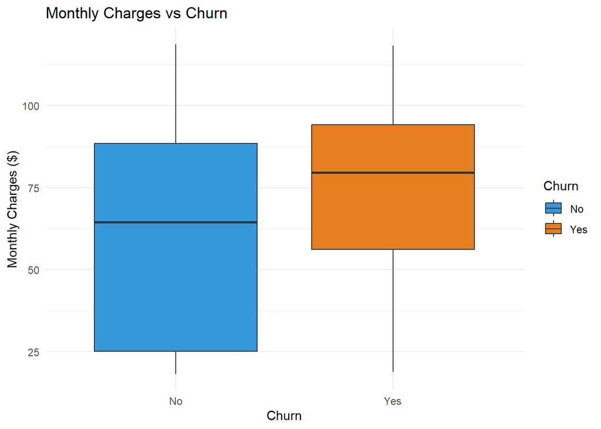

```r
ggplot(data_cleaned, aes(x = Churn, y = MonthlyCharges, fill = Churn)) +
  geom_boxplot() +
  scale_fill_manual(values = c("#3498db", "#e67e22")) +
  labs(title = "Monthly Charges vs Churn", x = "Churn", y = "Monthly Charges ($)") +
  theme_minimal()
```

**WHAT THIS ANALYSIS DOES & WHY IT MATTERS:** It helps detect if price sensitivity exists by showing if lost customers were paying more on average.

**Conclusion:** 1. Customers tend to churn if they find another competitor providing the same service at lower fees. 2. The current service does not provide enough unique value to differentiate it from competitors, making it easy to lose customers over price.

### C) Statistical Summary Table

```r
data_cleaned %>%
  group_by(Churn) %>%
  summarise(
    Customer_Count = n(),
    Average_Monthly_Charges = mean(MonthlyCharges, na.rm = TRUE),
    Median_Monthly_Charges = median(MonthlyCharges, na.rm = TRUE)
  )
```

```
## # A tibble: 2 × 4
##   Churn Customer_Count Average_Monthly_Charges Median_Monthly_Charges
##   <fct>          <int>                   <dbl>                  <dbl>
## 1 No              5174                    61.3                   64.4
## 2 Yes             1869                    74.4                   79.6
```

**WHAT THIS ANALYSIS DOES & WHY IT MATTERS:** This calculates the exact mathematical average and median spend for both customer groups.

**Key Insight:** Churned customers have a higher median monthly charge (~$79.65) compared to retained customers (~$64.42).

**Conclusion:** The company should introduce more attractive offers and localized loyalty programs for monthly contract customers to proactively reduce the churn rate.

### D) Monthly Charges Density by Churn Status (Density Plot)

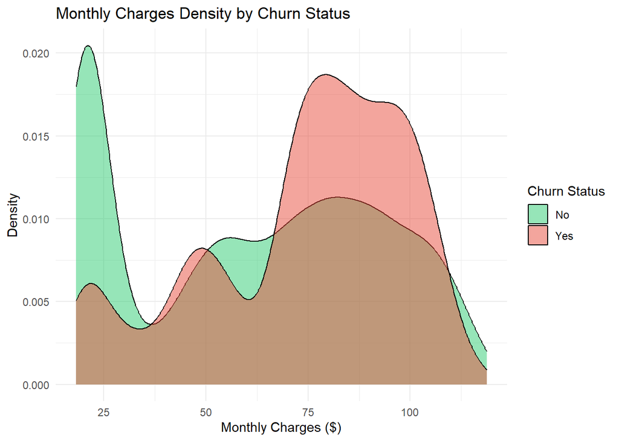

```r
ggplot(data_cleaned, aes(x = MonthlyCharges, fill = Churn)) +
  geom_density(alpha = 0.5) +
  scale_fill_manual(values = c("#2ecc71", "#e74c3c")) +
  labs(title = "Monthly Charges Density by Churn Status", x = "Monthly Charges ($)", y = "Density", fill = "Churn Status") +
  theme_minimal()
```

**WHAT THIS ANALYSIS DOES & WHY IT MATTERS:** This continuous density curve pinpoints the exact price points where customer loss is heaviest. It reveals the “danger zones” (e.g., bills over $70) where churn concentration peaks, guiding pricing adjustments.

## ## 4. Data Splitting & Imbalance Handling

```r
set.seed(123)
train_index <- createDataPartition(data_cleaned$Churn, p = 0.8, list = FALSE)

train_data <- data_cleaned[train_index, ]
test_data  <- data_cleaned[-train_index, ]

train_features <- train_data %>% select(tenure, MonthlyCharges, Contract, InternetService, TechSupport)
train_target <- train_data$Churn

train_data_balanced <- downSample(x = train_features, y = train_target, yname = "Churn")
```

**WHAT THIS ANALYSIS DOES & WHY IT MATTERS:** In real-world business data, loyal customers heavily outnumber churners. This data splitting and down-sampling balance the training dataset. This prevents the Machine Learning model from becoming biased, ensuring it accurately learns how to catch actual churners instead of blindly predicting “No Churn” for everyone just to look accurate.

**Key Technical Steps Applied:** * **Data Splitting:** The dataset is cleanly divided into 80% for training and 20% for testing. `set.seed(123)` is used to ensure perfect reproducibility. * **Handling Class Imbalance (Down-Sampling):** `downSample` was applied to balance the training classes, preventing majority class bias.

## ## 5. Predictive Modeling & Statistical Diagnostics

```r
churn_model <- glm(
  Churn ~ tenure + MonthlyCharges + Contract + InternetService + TechSupport,
  data = train_data_balanced,
  family = binomial(link = "logit")
)

summary(churn_model)
```

```
##
## Call:
## glm(formula = Churn ~ tenure + MonthlyCharges + Contract + InternetService +
##     TechSupport, family = binomial(link = "logit"), data = train_data_balanced)
##
## Coefficients: (1 not defined because of singularities)
##                                 Estimate Std. Error z value Pr(>|z|)
## (Intercept)                     0.209160   0.222027   0.942 0.346170
## tenure                         -0.032247   0.002846 -11.331  < 2e-16 ***
## MonthlyCharges                  0.012842   0.004538   2.830 0.004657 **
## ContractOne year               -0.845660   0.136066  -6.215 5.13e-10 ***
## ContractTwo year               -1.628875   0.207564  -7.848 4.24e-15 ***
## InternetServiceFiber optic      0.767691   0.197644   3.884 0.000103 ***
## InternetServiceNo              -0.888027   0.200238  -4.435 9.21e-06 ***
## TechSupportNo internet service        NA         NA      NA       NA
## TechSupportYes                 -0.555900   0.121240  -4.585 4.54e-06 ***
## ---
## Signif. codes:  0 '***' 0.001 '**' 0.01 '*' 0.05 '.' 0.1 ' ' 1
##
## (Dispersion parameter for binomial family taken to be 1)
##
##     Null deviance: 4147.8  on 2991  degrees of freedom
## Residual deviance: 2921.5  on 2984  degrees of freedom
## AIC: 2937.5
##
## Number of Fisher Scoring iterations: 5
```